# DATA 402 HW 3

Author

Sophia Chung

#### Section A: Math

##### 1)

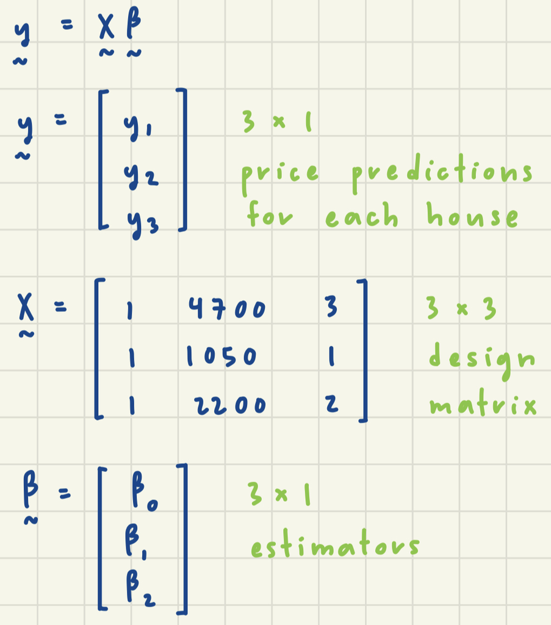

##### 2)

```r
X <- matrix(c(1, 4700, 3, 1, 1050, 1, 1, 2200, 2), nrow=3, ncol=3, byrow=T)
X
```

```
     [,1] [,2] [,3]
[1,]    1 4700    3
[2,]    1 1050    1
[3,]    1 2200    2
```

```r
hat_matrix <- round(X %*% solve(t(X) %*% X) %*% t(X))
hat_matrix
```

```
     [,1] [,2] [,3]
[1,]    1    0    0
[2,]    0    1    0
[3,]    0    0    1
```

The hat matrix is the identity matrix because we can predict house prices exactly. We have three estimators, one for each of our three observations. So, our predictions for $y$ equal our observations of $y$.

##### 3)

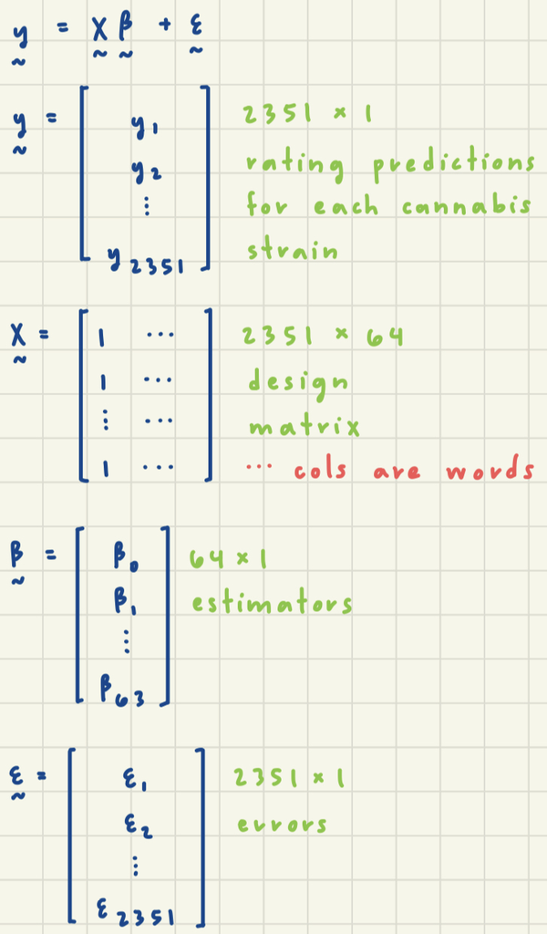

##### 4)

$\textbf{H} = \textbf{X}(\textbf{X}^T\textbf{X})^{-1}\textbf{X}^T$

I would expect this equation to “break” when we try to find an inverse because in this model, we have more observations than estimators.

##### 5)

$\textbf{H} = \textbf{X}(\textbf{X}^T\textbf{X} + \lambda\textbf{I})^{-1}\textbf{X}^T$

##### 6)

$\textbf{H} = \textbf{X}(\textbf{X}^T\textbf{X})^{-1}\textbf{X}^T$

The OLS hat matrix for this model predicting residuals is the same as my hat matrix in A2.

##### 7)

I would not recommend this strategy because it leaves too much room for error. The new model to predict the residuals has a random noise term itself. We are practically adding error upon error.

#### Section B: Programming

##### 1)

```r
cannabis <- read.csv('/Users/sophiapchung/Desktop/DATA 402/HW3/cannabis_full.csv')
cannabis <- cannabis[complete.cases(cannabis[,6:69]),]
```

I did not standardize any data because all of the predictors are categorical.

##### 2)

```r
beta_ols_estimates <- function(X, Y) {
  betas <- solve(t(X) %*% X) %*% (t(X) %*% Y)
  return (betas)
}
```

```r
X <- data.matrix(subset(cannabis, select=c(Type, Relaxed, Energetic)))
X <- cbind(rep(1, nrow(cannabis)), X)
Y <- data.matrix(subset(cannabis, select=c(Rating)))

beta_ols_estimates(X, Y)
```

```
             Rating
          3.7135370
Type      0.0295317
Relaxed   0.6155699
Energetic 0.3596050
```

##### 3)

```r
beta_ridge_estimates <- function(X, Y, lambda) {
  I <- diag(ncol(X))
  betas <- solve(t(X) %*% X + lambda*I) %*% (t(X) %*% Y)
  return (betas)
}
```

##### 4)

```r
beta_ridge_estimates(X, Y, 1000)
```

```
             Rating
          1.3254319
Type      0.9731231
Relaxed   0.9503940
Energetic 0.3104689
```

The Ridge intercept is lower than the OLS intercept. The Ridge Type and Relaxed coefficients are higher than the OLS Type and Relaxed coefficients. The Ridge Energetic coefficient is lower than the OLS Energetic coefficient.

##### 5)

```r
X <- data.matrix(subset(cannabis, select=-c(Strain, Rating, Effects, Flavor)))
X <- cbind(rep(1, nrow(cannabis)), X)
Y <- data.matrix(subset(cannabis, select=c(Rating)))

beta_ridge_estimates(X, Y, 1000)
```

```
                    Rating
              0.7646974704
Type          0.5663431180
Creative      0.2990997776
Energetic     0.2113252969
Tingly        0.1697807848
Euphoric      0.4611580293
Relaxed       0.5574012354
Aroused       0.1225061941
Happy         0.5306863923
Uplifted      0.4451556431
Hungry        0.1867952761
Talkative     0.1775433184
Giggly        0.1450007610
Focused       0.2235100295
Sleepy        0.2274289786
Dry           0.0023959242
Mouth         0.0023959242
Earthy        0.2630501753
Sweet         0.2682678670
Citrus        0.1664816762
Flowery       0.1102752238
Violet        0.0064700631
Diesel        0.1082353532
Spicy.Herbal  0.0997401139
Sage          0.0209195119
Woody         0.0572557292
Apricot       0.0029057973
Grapefruit    0.0149796795
Orange        0.0324066883
Pungent       0.1388320349
Grape         0.0639856106
Pine          0.1126370836
Skunk         0.0780203963
Berry         0.1251677906
Pepper        0.0405799656
Menthol       0.0142676909
Blue          0.0669585347
Cheese        0.0269530568
Chemical      0.0202919352
```

[output cut: 12 more lines]

```
Apple         0.0073876136
Honey         0.0204332651
Lavender      0.0208622496
Lime          0.0268602902
Coffee        0.0127705616
Ammonia       0.0162423119
Minty         0.0292926541
Tree          0.0092315695
Fruit         0.0092315695
Butter        0.0088251450
Pineapple     0.0093636058
Tar           0.0037786786
Rose          0.0070134461
Plum         -0.0005107638
Pear          0.0025295387
```

##### 6)

```r
tune_lambda_cv <- function(X, Y, metric, lambdas, splits) {
  indices <- sample(1:nrow(X))
  folds <- split(indices, cut(indices, breaks=splits, labels=FALSE))

  avg_metrics <- c()
  for (i in 1:length(lambdas)) {
    metrics <- c()
    for (j in 1:splits) {
      test_indices <- folds[[j]]

      X_test <- X[folds[[j]],]
      y_test <- Y[folds[[j]],]
      X_train <- X[-folds[[j]],]
      y_train <- Y[-folds[[j]],]

      betas <- beta_ridge_estimates(X_train, y_train, lambdas[i])
      pred <- X_test %*% betas

      if (metric == 'R-squared') {
        r_squared <- 1 - sum((y_test - pred)^2)/sum((y_test - mean(y_test))^2)
        metrics[j] <- r_squared
      }
      else if (metric == 'MSE') {
        metrics[j] <- mean(y_test - pred^2)
      }
      else if (metric == 'MAE') {
        metrics[j] <- mean(abs(y_test - pred))
      }
    }
    avg_metrics[i] <- mean(metrics)
  }

  if (metric == 'R-squared') {
    best_lambda <- lambdas[which.max(avg_metrics)]
  }
  else {
    best_lambda <- lambdas[which.min(avg_metrics)]
  }
  df <- data.frame('lambda'=lambdas, 'metric'=avg_metrics, 'best_lambda'=best_lambda)
  return (df)
}
```

##### 7)

```r
head(tune_lambda_cv(X, Y, 'R-squared', seq(1, 100, by=1), 10))
```

```
  lambda    metric best_lambda
1      1 0.3766878          11
2      2 0.3781250          11
3      3 0.3791616          11
4      4 0.3799283          11
5      5 0.3805023          11
6      6 0.3809317          11
```

```r
head(tune_lambda_cv(X, Y, 'MSE', seq(1, 100, by=1), 10))
```

```
  lambda    metric best_lambda
1      1 -14.62375           1
2      2 -14.61676           1
3      3 -14.61000           1
4      4 -14.60345           1
5      5 -14.59705           1
6      6 -14.59078           1
```

```r
head(tune_lambda_cv(X, Y, 'MAE', seq(1, 100, by=1), 10))
```

```
  lambda    metric best_lambda
1      1 0.3609730           8
2      2 0.3604781           8
3      3 0.3601362           8
4      4 0.3599099           8
5      5 0.3597564           8
6      6 0.3596534           8
```

Using R-squared, the best $\lambda$ is 11. We will use this value in our final model. Using MSE, the best $\lambda$ is 1. Using MAE, the best $\lambda$ is 8.

#### Section C: Concepts

##### 1)

To get the same results as I did in B5, I would have to plug in $\lambda*n$ or $2,305,000$ for alpha.

##### 2)

To get the same results as I did in B5, I would have to plug in $2\lambda*n$ or $4,610,000$ for penalty.

##### 3)

```r
betas <- beta_ridge_estimates(X, Y, 11)
betas <- betas[order(-betas),]
head(betas, 4)
```

```
            Relaxed  Creative  Euphoric
1.6329416 0.5985701 0.4832099 0.4700200
```

##### 4)

```r
library(glmnet)
lasso <- glmnet(X, Y, alpha=1, lambda=2*11*2305)
# lasso <- glmnet(X, Y, alpha=1, lambda=2*11*2305, standardize=FALSE)
coef(lasso)
```

```
67 x 1 sparse Matrix of class "dgCMatrix"
                   s0
(Intercept)  4.318829
             0.000000
Type         .
Creative     .
Energetic    .
Tingly       .
Euphoric     .
Relaxed      .
Aroused      .
Happy        .
Uplifted     .
Hungry       .
Talkative    .
Giggly       .
Focused      .
Sleepy       .
Dry          .
Mouth        .
Earthy       .
Sweet        .
Citrus       .
Flowery      .
Violet       .
Diesel       .
Spicy.Herbal .
Sage         .
Woody        .
Apricot      .
Grapefruit   .
Orange       .
Pungent      .
Grape        .
Pine         .
Skunk        .
Berry        .
Pepper       .
Menthol      .
Blue         .
```

[output cut: 14 more lines]

```
Apple        .
Honey        .
Lavender     .
Lime         .
Coffee       .
Ammonia      .
Minty        .
Tree         .
Fruit        .
Butter       .
Pineapple    .
Tar          .
Rose         .
Plum         .
Pear         .
```

##### 5)

It is important to standardize our predictors in the Ridge and LASSO model fitting approaches. With Ridge and LASSO, we do not want penalties to be unfairly applied to predictors of different scales.

##### 6)

In this data scenario, I prefer the Ridge approach. The LASSO approach did not reveal much useful information.